# Setup: RStudio

Zach del Rosario 2020-05-02

*Purpose*: We’re going to make extensive use of the [R programming language](https://www.r-project.org/about.html); in particular, the [Tidyverse](https://www.tidyverse.org/) packages. This first exercise will guide you through setting up the necessary software.

*Reading*: (None)

**q1** Install Rstudio

Download [RStudio Desktop](https://rstudio.com/products/rstudio/download/) and install the [R programming language](https://cran.rstudio.com/). Both are free!

Once installed, you can [download the source](https://github.com/zdelrosario/data-science-curriculum/blob/master/exercises/e-setup00-install.Rmd) for this exercise and open open it in RStudio (or you can follow `e-rep01-intro-git` and *clone* the repository). This is an `R Markdown` file, which is a combination of human-readable text and machine-readable code. Think of it as a modern take on a lab notebook.

**q2** Install packages

Next, run RStudio. When the program opens, you should see a console tab, as in the image below.

[figure not shown]

Note that RStudio has multiple tabs, including the `Console`, `Terminal`, `Jobs`, and any files you may have opened. Make sure you are in the `Console` tab.

Type the line `install.packages("tidyverse")` in your `Console` and press Enter. This will start the installation of the `tidyverse` package, which we will use extensively in this class.

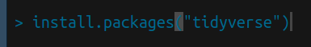

**q3** Test your install

Once your installation has finished, return to your console and use the command `library(tidyverse)`. If your installation is complete, this command should return a list of packages and version numbers, similar to the image below.

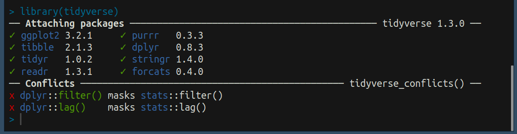

If you have any issues with installation, **please** let me know!

**q4** Download extras

We’ll use a number of extras for this class. To that end, please install the following packages.

- `curl`
- `mvtnorm`
- `nycflights13`
- `gapminder`
- `ggrepel`
- `googlesheets4`
- `viridis`

**q5** Download cheatsheets

The `tidyverse` is essentially a language built on top of R. As such, there are a lot of functions to remember. To that end, RStudio has put together a number of [cheatsheets](https://rstudio.com/resources/cheatsheets/) to reference when doing data science. Some of the most important ones are:

- [Data visualization](https://github.com/rstudio/cheatsheets/raw/master/data-visualization-2.1.pdf)
- [Data transformation](https://github.com/rstudio/cheatsheets/raw/master/data-transformation.pdf)
- [Data importing](https://github.com/rstudio/cheatsheets/raw/master/data-import.pdf)

Later, we will learn special tools for handling:

- [String data](https://github.com/rstudio/cheatsheets/raw/master/strings.pdf)
- [Dates and times](https://github.com/rstudio/cheatsheets/raw/master/lubridate.pdf)
- [Factors](https://github.com/rstudio/cheatsheets/raw/master/factors.pdf)
- [R Markdown](https://github.com/rstudio/cheatsheets/raw/master/rmarkdown-2.0.pdf)

# Exit Ticket

For every exercise, your deliverable will to complete an “exit ticket”. Make sure to follow the survey link at the end of every exercise and submit the survey to get credit for your work! Note that in RStudio you can Ctrl + Click (CMD + Click) to follow a link.

Once you have completed this exercise, make sure to fill out the **exit ticket survey**, [linked here](https://docs.google.com/forms/d/e/1FAIpQLSeuq2LFIwWcm05e8-JU84A3irdEL7JkXhMq5Xtoalib36LFHw/viewform?usp=pp_url&entry.693978880=e-setup00-install.Rmd).